# diffusion slides

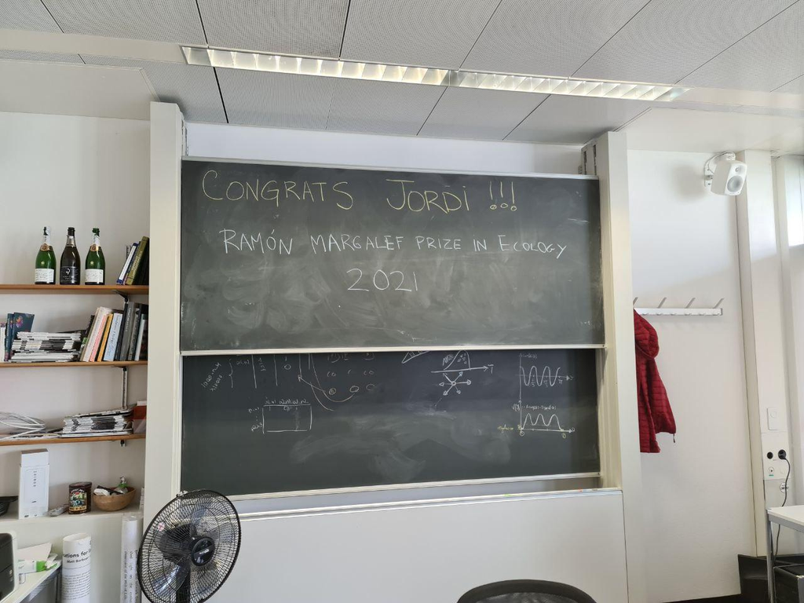

```python
from IPython.display import Image
Image("jordibascompte.jpg")
```

```python
from IPython.core.display import display, HTML
display(HTML("""<a href="https://govern.cat/gov/">Jordi Bascompte Margalef Prize ceremony</a>"""))
```

[Jordi Bascompte Margalef Prize ceremony](https://govern.cat/gov/)

## Trait dynamics: diffusion equations between ecology and evolution

## Learning today

- dynamics null models in ecology and evolution (i.e., diffusion, flow, random walks, Brownian motion, neutral fitness)
- diffusion in single networks
- an incipient diffusion modeling in multiplex mutualistic networks

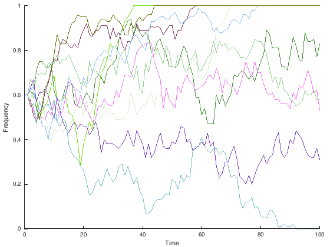

```python
###### DRIFT -- A simple example in octave simulating random fluctuations of phenotypes in a population
graphics_toolkit();available_graphics_toolkits();
loaded_graphics_toolkits();graphics_toolkit("gnuplot");addpath(genpath(pwd))
pkg load statistics
for r = 1:10;N = 100;count = 0;G = 100;
    for i = 2:G;
        P(1,1) = 0.6;count = count + 1;#initial condition
        X = binornd(N,P(count,1));
        #Return a matrix of random samples from the binomial distribution with parameters
        #N and P, where N is the number of trials and P  is the probability of success.
        P(i,1) = X/N;
    end
    n = 1:G;
    for j = 1:N;hold on
           t1 =unifrnd(0,1);t2 =unifrnd(0,1);t3 =unifrnd(0,1);
           h = plot(n,P,'k');set(h,'color',[t1 t2 t3]);hold on
           xlabel("Time")
           ylabel("Frequency")
    end
end
```

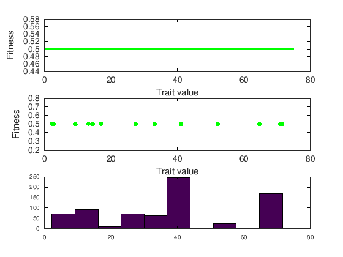

```python
#There can be many fitness functions describing the relationship between
#trait value and fitness -- We will explore a few of them. First we will
#explore random drift assuming all individuals have equal fitness -- lets call this
#a neutral scenario
graphics_toolkit();available_graphics_toolkits();
loaded_graphics_toolkits();graphics_toolkit("gnuplot")
addpath(genpath(pwd))
pkg load statistics
ecoevo4
```

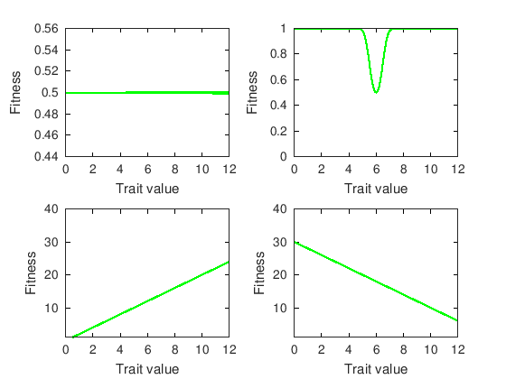

```python
#some examples with different fitness functions
graphics_toolkit();
available_graphics_toolkits();
loaded_graphics_toolkits();
graphics_toolkit("gnuplot")
addpath(genpath(pwd))
pkg load statistics
ecoevo5
```

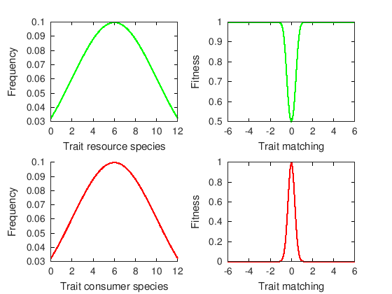

```python
#A simple example of fitness of a trait value for one resource and one consumer
graphics_toolkit();
available_graphics_toolkits();
loaded_graphics_toolkits();
graphics_toolkit("gnuplot")
addpath(genpath(pwd))
pkg load statistics
ecoevo1
```

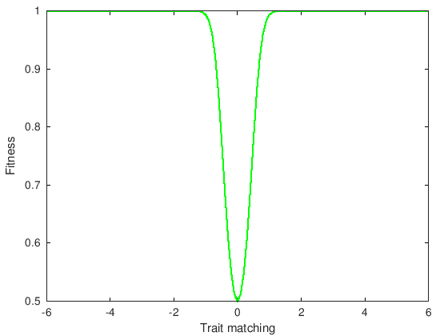

```python
%Fitness function for resources==================================================================
gamma = 5;%Strength of interaction between resource (trait value Zr) and consumer (trait value Zc)
for pB = 1:length(Zr);
WB(pB,2) = 1/(1 + exp(-gamma*(Zr(1,pB) - mean(Zc))^2));
WB(pB,1) = Zr(1,pB) - mean(Zc);
end
hr1 = plot(WB(:,1),WB(:,2),'g',"markersize", 12);%Visualize
%a =unifrnd(0,1);
%b =unifrnd(0,1);
%c =unifrnd(0,1);
%set(hr1,'color',[a b c]);
set(hr1,'LineWidth',4);
%title('Resource',"fontsize",10)
xlabel('Trait matching',"fontsize",14)
ylabel('Fitness',"fontsize",14)
set(gca,'fontsize',14);
%===================================================================================
```

### ... the resource fitness function producing the top right hand side plot above is

$$w(\phi) = \frac{1}{1 + e^{-\gamma(\phi_{R} - \overline{\phi}_{C})^2}}$$

```python
%which in octave is written as

%Fitness function for resources==================================================================

gamma = 5;%Strength of interaction between resource (trait value Zr) and consumer (trait value Zc)
for pB = 1:length(Zr);
    WB(pB,2) = 1/(1 + exp(-gamma*(Zr(1,pB) - mean(Zc))^2));
    WB(pB,1) = Zr(1,pB) - mean(Zc);
end
```

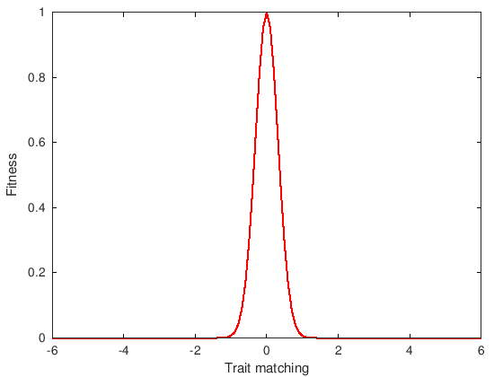

```python
%Fitness function for consumers==================================================================
gamma = 5;%Strength of interaction between resource (trait value Zr) and consumer (trait value Zc)
for pB = 1:length(Zr);
    WB(pB,2) = exp(-gamma*(Zr(1,pB) - mean(Zc))^2);
    WB(pB,1) = Zr(1,pB) - mean(Zc);
end
hr1 = plot(WB(:,1),WB(:,2),'r',"markersize", 12);%Visualize
%a =unifrnd(0,1);
%b =unifrnd(0,1);
%c =unifrnd(0,1);
%set(hr1,'color',[a b c]);
set(hr1,'LineWidth',4);
%title('Consumer',"fontsize",10)
xlabel('Trait matching',"fontsize",14)
ylabel('Fitness',"fontsize",14)
set(gca,'fontsize',14);
```

#### and the consumer fitness function producing the bottom right hand side plot above is

$$w(\phi) = e^{-\gamma(\phi_{R} - \overline{\phi}_{C})^2}$$

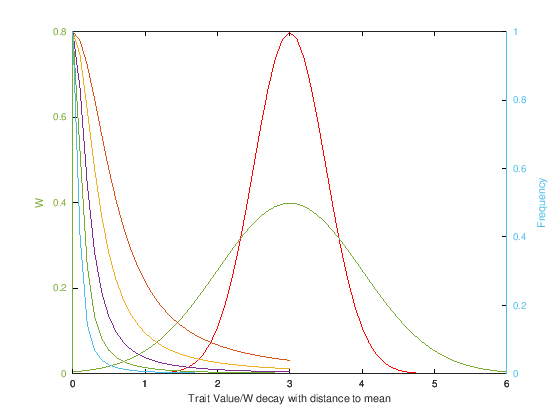

```python
%a more intuitive way of visualizing Figure 1 for the consumers is the following Figure 2
ecoevo2 %plots Figure 2

%on the left side of this plot we represent the decay in fitness when the trait value of a consumer
%deviates from the the mean trait value of the resource (maximum value with deviation equals to zero...).
%Trait distributions are the resource and consumer populations
```

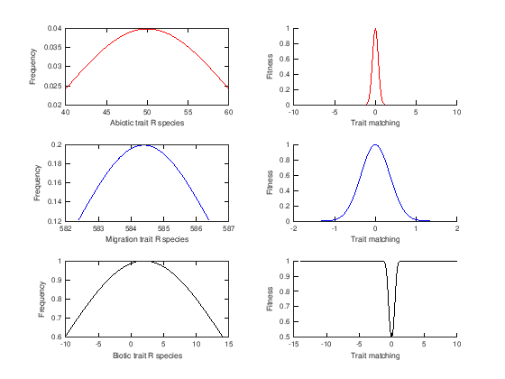

```python
ecoevoresource2
%we can think more broadly - each trait as a layer - for example each individual can be formed by three traits,
%abiotic, dispersal and biotic --- assuming independence among these traits
%we can plot the same figure as we did before only for the biotic trait
```

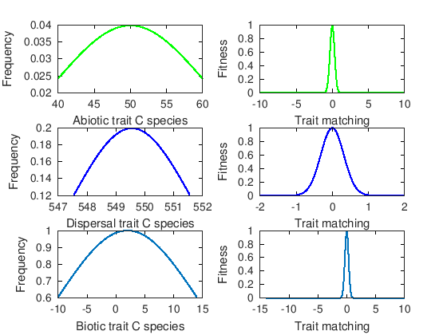

```python
ecoevoconsumer3
%and the same for the consumers. Notice the mean phenotype now increases fitness along the three traits
```

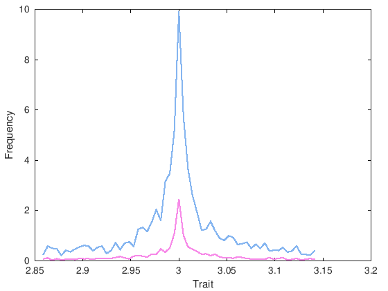

```python
ecoevo4mfd #the dynamics of positive frequency-dependent selection,
%only the common types both in the resorces and the consumers persist
%======download the required octave packages to visualize the animation======
```

### DIFFUSION on single networks

[figure not shown]

### DIFFUSION on single networks

Given : $x_i$ as a continuous trait variable assigned to each node (individual) $i = 1,2,...,N$,

$\frac{\textit{d}x_{i}}{\textit{d}t}$ = $\sum_{j}^{N} a_{ij} (x_{j} - x_{i})$

and in matrix form

$\frac{\textit{d}{\bf x}}{\textit{d}t}$ = $-\mathcal{L}{\bf x}$

${\bf x}$ is the vector describing the dynamical state of each node (individual), i.e., ${\bf x}$ = $(x_{1}, x_{2}, x_{N})^{T}$

$\mathcal{L}$ is the Laplacian matrix of the network having elements (as matrix form)

$\mathcal{L}$ = $\mathcal{D}$ - $\mathcal{A}$

where $\mathcal{D}$ is the degree matrix (i.e., the degree of each node in the diagonal and the rest of values equal to zero) and $\mathcal{A}$ is the adjancency matrix (i.e., $a_{ij}$ = 1 or 0). This can also be represented as in cell form as

$L_{ij}$ = $k_{i} \delta_{ij} - a_{ij}$

```python
## Difusion on single graphs
graphics_toolkit();
available_graphics_toolkits();
loaded_graphics_toolkits();
graphics_toolkit("gnuplot")

addpath(genpath(pwd))
pkg load statistics

N = 20; #Number of nodes
A = zeros(N, N);
Adj = zeros(N * N, N * N); % The adjacency matrix
size(Adj);


% Use 8 neighbors, and fill in the adjacency matrix (as an example)
dx = [- 1, 0, 1, - 1, 1, - 1, 0, 1];
dy = [- 1, - 1, - 1, 0, 0, 1, 1, 1];
for x = 1:N
    for y = 1:N
        index = (x - 1) * N + y;
        for ne = 1:length(dx)
            newx = x + dx(ne);
            newy = y + dy(ne);
            if newx > 0 && newx <= N && newy > 0 && newy <= N
                index2 = (newx - 1) * N + newy;
                Adj(index, index2) = 1;
            end
        end
    end
end

## COMPUTES THE SOLUTION TO THE DIFFERENTIAL EQUATION
Deg = diag(sum(Adj, 2)); % Compute the degree matrix
L = Deg - Adj; % Compute the laplacian matrix in terms of the degree and adjacency matrices
[V, D] = eig(L); % Compute the eigenvalues/vectors of the laplacian matrix
D = diag(D);

## Initial condition (place a few large positive values around and make everything else zero)
C0 = zeros(N, N);
C0(2:5, 2:5) = 5;
C0(10:15, 10:15) = 10;
C0(2:5, 8:13) = 7;
C0 = C0(:);

C0V = V'*C0; % Transform the initial condition into the coordinate system of the eigenvectors
for t = 0:0.1:1
    % Loop through times and decay each initial component
    Phi(t,1) = t;
    Phi(t,2) = C0V .* exp(- D * t); % Exponential decay for each component
end
size(D)
plot(Phi(:,1),Phi(:,2))
```

[output not shown]

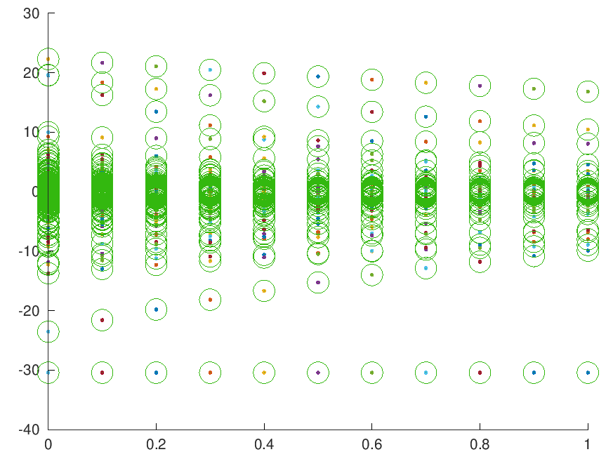

```python
### DIFFUSION on multiplex network
from IPython.display import Image
Image("singlediffusion.png")
```

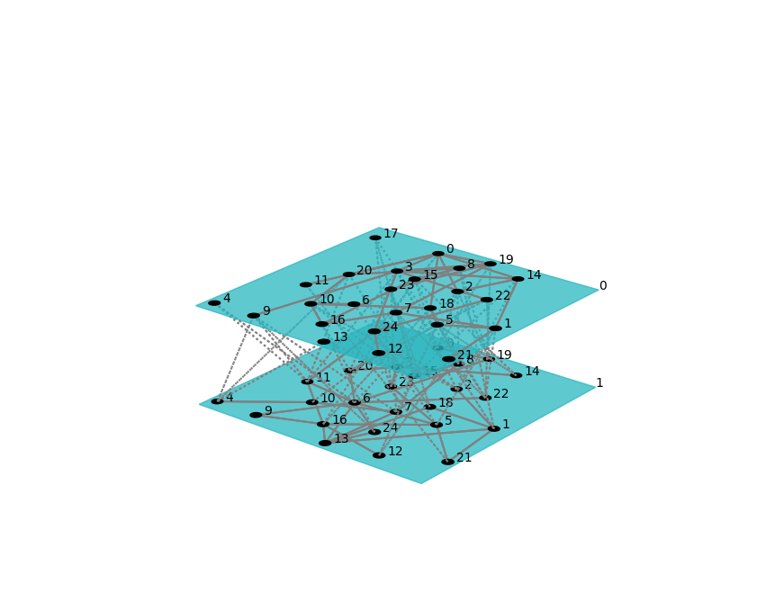

```python
### DIFFUSION on multiplex networks
from IPython.display import Image
Image("Figure2.png")
```

### DIFFUSION on multiplex network

Given : $x_i^{[\alpha]}$ as a continuous trait variable assigned to each node (individual) $i = 1,2,...,N_{p}$ in layers $\alpha = 1, 2, ..., N_{a}$ and both intralinks and interlinks can sustain diffusion dynamics, then

$\frac{\textit{d}x_{i}^{[\alpha]}}{\textit{d}t}$ = $\mathcal{D}^{[\alpha]}$ $\sum_{j=1}^{N_{p}} w_{ij}^{[\alpha]} (x_{j}^{[\alpha]} - x_{i}^{[\alpha]})$ + $\sum_{k=1}^{N_{a}} \mathcal{D}^{[\alpha,\beta]} (x_{k}^{[\beta]} - x_{i}^{[\alpha]})$

and in matrix form

$\frac{\textit{d}{\bf X}}{\textit{d}t}$ = $-\mathcal{L}{\bf x}$,

where $\mathcal{L}$ is an ($N_{p}$ $\cdot$ $N_{a}$) x ($N_{p}$ $\cdot$ $M_{a}$) matrix called the $supra$-$Laplacian$ $matrix$, and ${\bf X}$ is an $N_{p}$ $\cdot$ $N_{a}$ vector describing the dynamical state of each node in the multilayer network.

# Take home message

#### Neutral models

#### Fitness functions and selection types

#### Diffusion in single networks and multiplex networks